# Graphical Analyses of Expanded Acne Dataset

TamTo

2023-10-07

I’m working with the acne dataset I expanded (NewLymphocyteClusters Seurat object). Here we will analyze the data in various graphical forms to let us generate hypotheses and confirm results we may see in wet lab experiments.

To easily find genes of interest and their expression level, you can make feature maps, dot plots, etc.

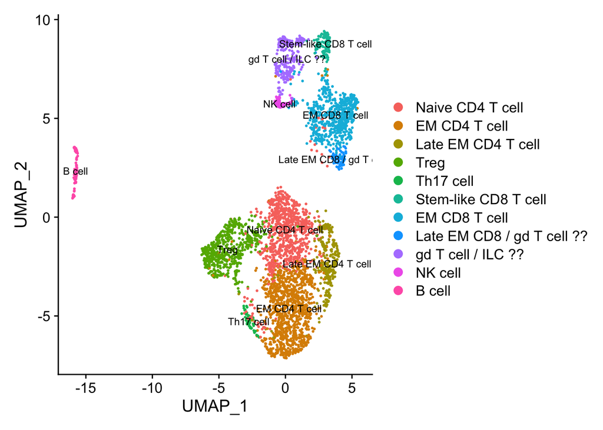

```r
# View the UMAP of our Seurat object to look at our cell types again.
DimPlot(object = NewLymphocyteClusters, reduction = "umap", label = TRUE, label.size = 3)
```

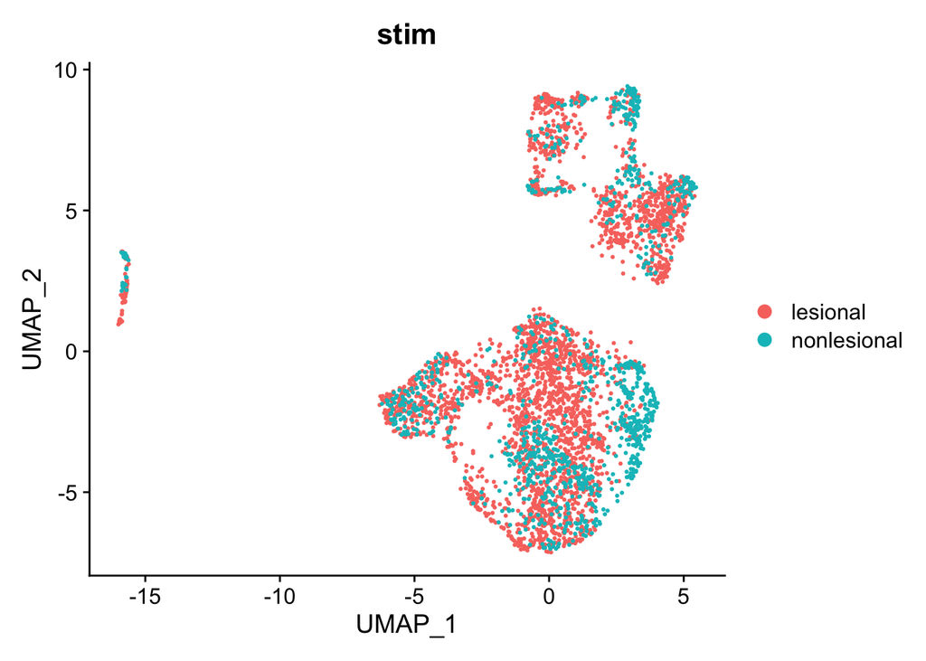

```r
# We can also view it based on nonlesional skin or by the acne lesional skin or we can use the split.by function to split the data according to lesion sample as well.
DimPlot(object = NewLymphocyteClusters, reduction = "umap", group.by = "stim", label = FALSE)
```

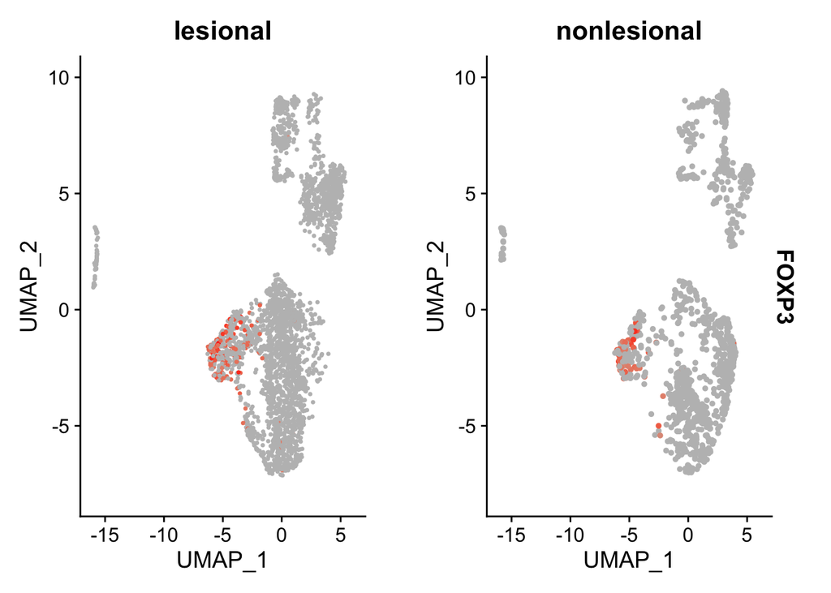

```r
# View gene expression on the UMAP. Here, we see that FOXP3 is expressed mainly only in the Treg cluster on our UMAP. You can  split.by = "stim" to view it by lesion vs. nonlesional--in doing so, we see it is more highly expressed in lesional.
FeaturePlot(object = NewLymphocyteClusters, features = c("FOXP3"), split.by = "stim", cols = c("gray", "red"))
```

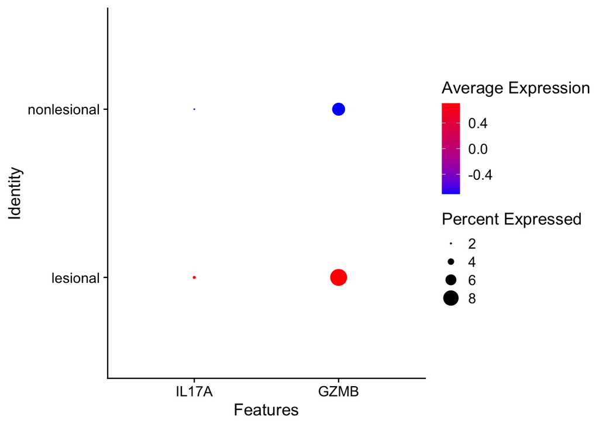

```r
# View gene expression by dot plot. You can use group.by to view what genes may be more highly expressed in nonlesional vs. lesional. Here, it looks like the proinflammatory gene IL17A and cytolytic protease gene GZMB are upregulated in acne lesions.
DotPlot(object = NewLymphocyteClusters, features = c("IL17A", "GZMB"), group.by = "stim", cols = c("blue", "red"))
```

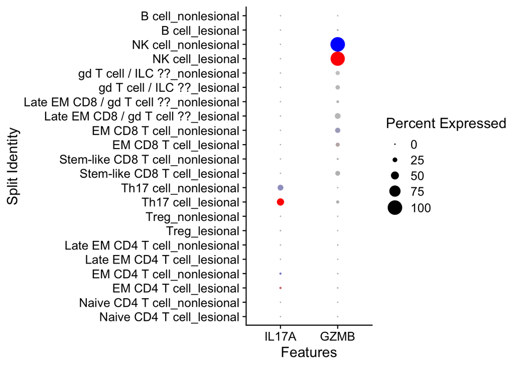

```r
# You can see which cell types express the gene the most as well as in which lesion.
DotPlot(object = NewLymphocyteClusters, features = c("IL17A", "GZMB"), group.by = "celltype", split.by = "stim", cols = c("red", "blue"))
```

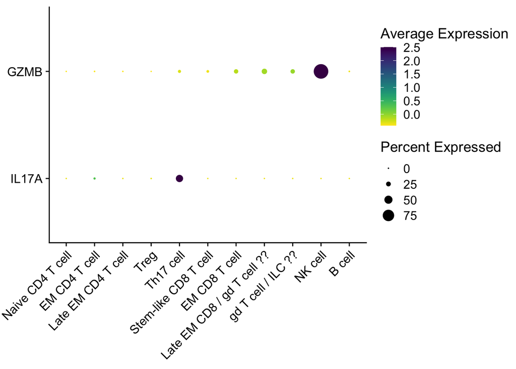

```r
# To more aesthetically visualize which cell type expresses the gene, I like to use the scCustomize functions.
DotPlot_scCustom(seurat_object = NewLymphocyteClusters, features = c("IL17A", "GZMB"), flip_axes = TRUE, x_lab_rotate = TRUE, colors_use = viridis_dark_high)
```

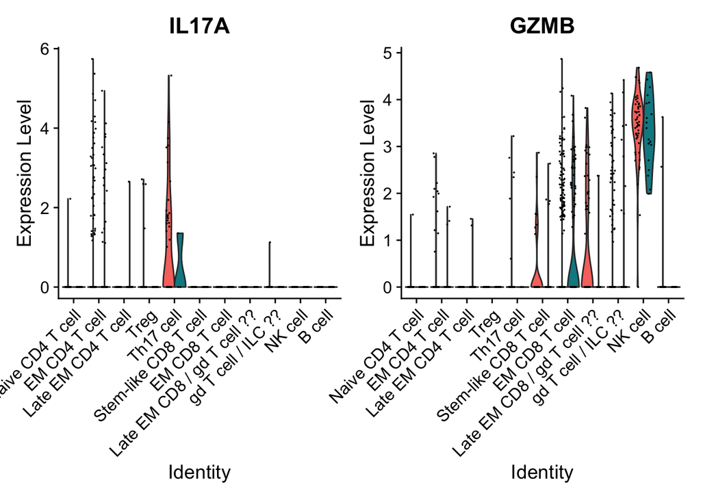

```r
# We can visualize these genes by violin plots as well. This confirms what we saw in our dot plots.
VlnPlot(object = NewLymphocyteClusters, features = c("IL17A", "GZMB"), split.by = "stim", pt.size = .001)
```

[figure not shown]

```r
# If we want to visualize lots of genes in one graph, I recommend creating a stacked violin plot. Likewise, this can be done with the stacked dot plot as well.

features <- c("PTPRC", "CD3E", "CD3G", "CD3D", "TRAC", "TRBC1", "TRBC2", "BCL11B", "CD4", "CD28", "CCR7", "SELL", "FOXP3", "IL2RA", "IL17A", "IL26", "CXCL13", "RORC", "CD8A", "CD8B", "TCF7", "XCL1", "GZMB", "PRF1", "GNLY", "TRDC", "TRGC1", "TRGC2", "IL7R", "KIT", "ICOSLG", "TNFSF4", "NCAM1", "KLRB1", "NOTCH3", "IRF8", "AREG", "FCGR3A", "KLRD1", "TBX21", "MZB1", "JCHAIN")

VlnPlot(NewLymphocyteClusters, features, stack = TRUE, sort = FALSE, flip = TRUE) +
        theme(legend.position = "none")
```

Sometimes, we only want to look at certain cell types (ex: only CD4s, or only CD8s, etc.) and analyze gene expression in only those clusters. In this case, we have to subset them from the rest of the clusters. Let’s say we’re only interested in the CD8 clusters.

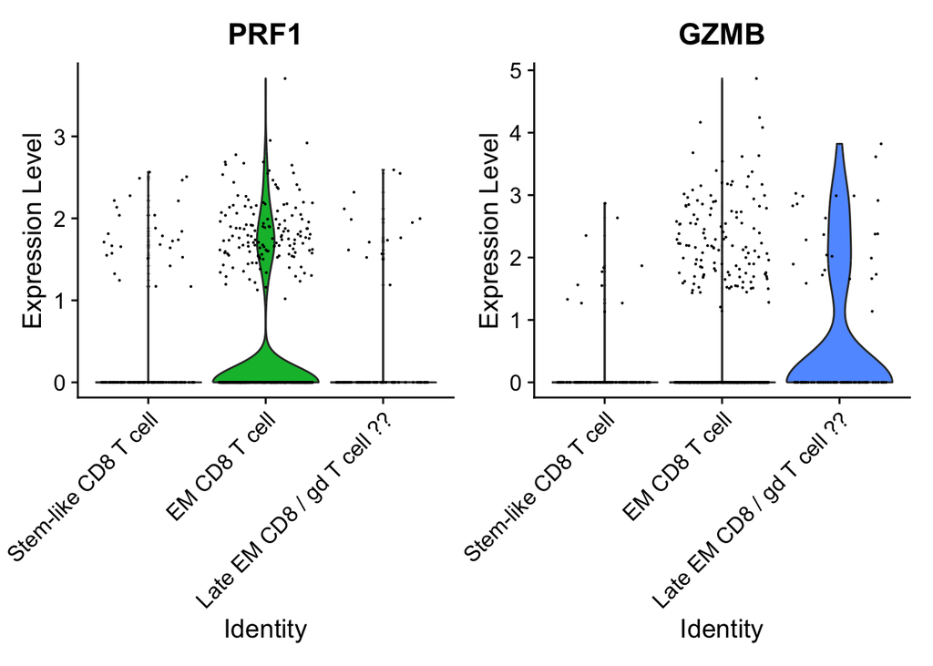

```r
# Look at what the active cell identities are and check the order of the levels
# Idents(object = NewLymphocyteClusters)
# levels(x = NewLymphocyteClusters)

# First stash the cell identity classes.
NewLymphocyteClusters[["old.ident"]] <- Idents(object = NewLymphocyteClusters)

# Now we can subset seurat object based on identity class.
CD8subset <- subset(x = NewLymphocyteClusters, idents = c("Naive CD4 T cell", "EM CD4 T cell", "Late EM CD4 T cell", "Treg", "Th17 cell", "gd T cell / ILC ??", "NK cell", "B cell"), invert = TRUE)

# To confirm that we have subsetted our clusters of interest, we can make plots! In this case, PRF1 is most highly expressed in EM CD8 T cells and GZMB is most highly expressed in the Late EM CD8 / gd T cells.
VlnPlot(object = CD8subset, features = c("PRF1", "GZMB"))
```

We can also visualize the data and compare cell proportions in each lesion (i.e. whether cell types may be differentially expressed in frequency). To do so, we can use the dittoSeq package to generate stacked bar plots. You can install the package through installing the BiocManager package (ensures the appropriate Bioconductor installation is compatible with the right version of R).

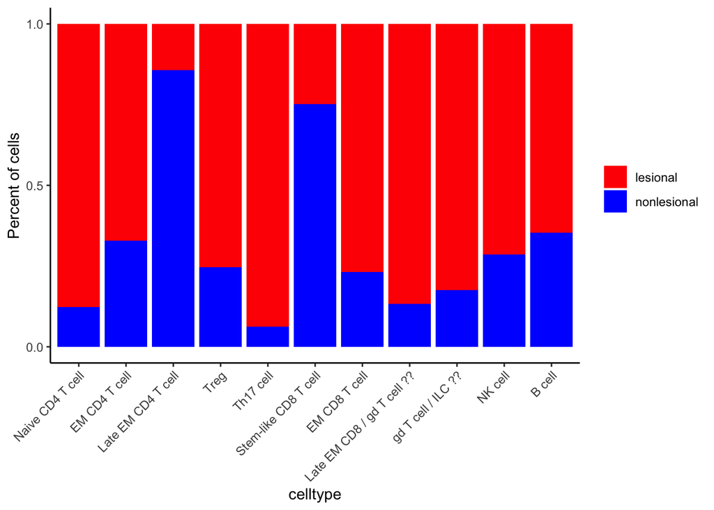

```r
# if (!require("BiocManager", quietly = TRUE))
#    install.packages("BiocManager")

# BiocManager::install("dittoSeq")

library(BiocManager)
library(dittoSeq)

# Create a bar plot that shows the cell type proportion split by nonlesional/lesional. Here, we see that all cell types except for Late EM CD4 T cells and Stem-like CD8 T cells are in greater frequency within the lesional samples than the nonlesional samples.

dittoBarPlot(
    object = NewLymphocyteClusters,
    var = "stim",
    group.by = "celltype",
    main = NULL,
    color.panel = c("red", "blue"),
    x.reorder = c(7, 2, 5, 11, 10, 9, 3, 6, 4, 8, 1), # make sure to reorder the clusters for visual consistency on the axes
    )
```